# Project 4

Jai Jeffryes, Tamiko Jenkins, Nicholas Chung

11/3/2019

# Project 4

## Assignment

Analyze a corpus of emails classified as spam or legitimate (dubbed “ham”). Develop a predictive process for classifying new email correctly.

```r
library(readr)
library(stringr)
library(dplyr)
```

```r
library(tibble)
library(tidyr)
library(tidytext)
library(ggplot2)
library(tm)
library(caret)
library(wordcloud2)
library(LiblineaR)
```

## Approach

The following describes our general approach towards a predictive model for classifying emails: 1. utilize the Tidyverse toolkit to clean and tokenize the dataset 2. create a Document Term Matrix (DTM) to describe the frequency of terms in the dataset 3. visualize descriptive findings with barcharts and wordclouds 4. apply a machine learning model to develop a predictive classification model

### Tidyverse

We utilize Tidyverse tools for text mining enable data input, cleansing, and tokenization. It is additionally possible to cast tidy structures to a DTM.

*Reference*: [Text Mining with R: A Tidy Approach](https://www.tidytextmining.com).

### Document Term Matrix

A key data structure in text mining is the DTM. DTMs serve as the input format for many machine learning models.

### Machine learning

We classify emails by employing a Support Vector Machine model from the `caret` package.

## 1. Read emails

```r
# Directories for emails
dir_spam <- "data/spam"
dir_ham <- "data/easy_ham"

# File lists
fils_ham <- list.files(dir_ham, full.names = TRUE)
fils_spam <- list.files(dir_spam, full.names = TRUE)

# Filter file count
max_fils <- 500
fils_ham <- fils_ham[1:(min(max_fils, length(fils_ham)))]
fils_spam <- fils_spam[1:(min(max_fils, length(fils_spam)))]

# Function for input
get_text_df <- function(files, class) {
  raw_email <- sapply(files, function(x) read_file(x, locale=locale(encoding="latin1")))
  # Pick off key value on end of file names
  id <- str_extract(files, "\\w*$")
  # Corpus in tidy format. Each row is a document.
  text_df <- tibble(id = id, class = as.factor(class), email = raw_email)
  return(text_df)
}

# Input
ham_df <- get_text_df(fils_ham, "ham")
spam_df <- get_text_df(fils_spam, "spam")

# Merge the documents into one corpus
email_df <- rbind(ham_df, spam_df)

# Free some memory
rm(list = c("ham_df", "spam_df"))
gc()
```

```
##           used  (Mb) gc trigger  (Mb) max used  (Mb)
## Ncells 2037865 108.9    4096487 218.8  2672482 142.8
## Vcells 3663452  28.0    8388608  64.0  6536288  49.9
```

## 2. Clean

We start cleaning by removing headers. By specification, email headers may not contain blank lines; we apply regular expression to strip the headers.

**Notes on regular expression**: - `.*?\n\n`: The question mark enables non-greedy matching of any text in order to match up to the first double line break. The solution isn’t perfect: there are some headers with multiple instances of blank lines. Nevertheless, most of the headers are removed and the solution appears adequate for our purposes. - Our experience found `stringr` to be inferior in performance to base R for this string manipulation. However, our base R code requires more testing to fix a bug that allows some headers through.

```r
# Remove headers
# Tibbles: they're great -- no strings as factors, no row names
email_bodies <- tibble(email = sapply(email_df$email, function(x) {
    sub(".*?((\r|\n)\n){2}", "", x)
}))

# Replace email column with bodies
email_df <- cbind(email_df[, 1:2], email_bodies)
```

## 3. Tokenize

This approach creates a tall, narrow dataframe of tokens.

We get some cleaning for free from the `unnest()` function. - Remove punctuation; - Convert to lower case; and - Remove white space

**Notes on possibilities for additional cleaning** - Stemming: we can enable improved analysis by reducing words to their root form, or stem. This would have the additional benefit of reducing the size of the DTM.

```r
# Look at 2 emails for validation
# dplyr retrieval is easy, as is filtering and aggregation
email_df %>%
  select(email) %>%
  sample_n(2)
```

```
##                                                                                                                                                                                                                                                                                                          …
## 1 John P. Looney stated the following on Thu, Aug 29, 2002 at 03:31:11PM +0100 :\r\n>  I'm not sure what exactly is wrong with this, but I can't get a redhat\r\n> 7.1 box to use ttyS0 as a console.\r\n> \r\n>  The relevant bits of /boot/grub/grub.conf are:\r\n> \r\n> serial --unit=0 --speed=11520…
## 2                                                                                                                                                                                        Adam Beberg:\r\n>Considering 90% of the fake job posting I see are for embedded systems or \r\n>device drivers -…
```

```r
# Tokenize all emails
email_tokens_df <- email_df %>%
  unnest_tokens(word, email) %>%
  anti_join(stop_words)
```

### Check counts for validation

```r
email_tokens_df %>%
  count(word, sort = TRUE)
```

```
## # A tibble: 11,972 x 2
##    word      n
##    <chr> <int>
##  1 3d     3532
##  2 font   2718
##  3 br     1810
##  4 td     1493
##  5 http   1407
##  6 size   1055
##  7 tr      924
##  8 color   788
##  9 width   787
## 10 1       638
## # ... with 11,962 more rows
```

### Ham Word Cloud

```r
email_tokens_df %>%
  filter(class == "ham") %>% count(word) %>% wordcloud2
```

[interactive chart not shown]

### Spam Word Cloud

```r
email_tokens_df %>%
  filter(class == "spam") %>% count(word) %>% wordcloud2
```

[interactive chart not shown]

## 4. Term Frequency–Inverse Document Frequency

We calculate term frequency and inverse document frequency (TD-IDF) to enable producing a DTM.

```r
email_tf_idf <- email_tokens_df %>%
  count(class, word, sort = TRUE) %>%
  ungroup() %>%
  bind_tf_idf(word, class, n)

email_tf_idf %>%
  arrange(-tf_idf)
```

```
## # A tibble: 13,669 x 6
##    class word       n      tf   idf  tf_idf
##    <fct> <chr>  <int>   <dbl> <dbl>   <dbl>
##  1 spam  td      1493 0.0250  0.693 0.0173
##  2 spam  tr       924 0.0155  0.693 0.0107
##  3 spam  align    532 0.00891 0.693 0.00618
##  4 spam  height   450 0.00754 0.693 0.00522
##  5 spam  border   391 0.00655 0.693 0.00454
##  6 spam  img      315 0.00527 0.693 0.00366
##  7 spam  arial    308 0.00516 0.693 0.00358
##  8 ham   rpm       94 0.00439 0.693 0.00304
##  9 spam  span     249 0.00417 0.693 0.00289
## 10 ham   exmh      86 0.00402 0.693 0.00278
## # ... with 13,659 more rows
```

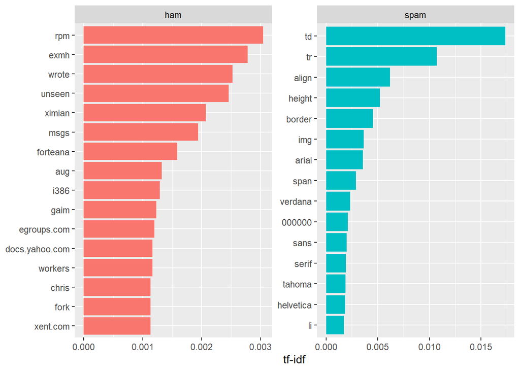

```r
email_tf_idf %>%
  arrange(desc(tf_idf)) %>%
  mutate(word = factor(word, levels = rev(unique(word)))) %>%
  group_by(class) %>%
  top_n(15) %>%
  ungroup() %>%
  ggplot(aes(word, tf_idf, fill = class)) +
  geom_col(show.legend = FALSE) +
  labs(x = NULL, y = "tf-idf") +
  facet_wrap(~class, ncol = 2, scales = "free") +
  coord_flip()
```

## 5. Document Term Matrix

We make our first departure from Tidy formats to a format readily utilizable by ML models. We cast counts to a DTM, then inspect and reduce some of the sparseness.

```r
# Word counts
word_counts <- email_tokens_df %>%
  count(id, word, sort = TRUE) %>%
  ungroup()

# Cast to a document term matrix
email_dtm <- word_counts %>%
  cast_dtm(id, word, n)

# Print
dim(email_dtm)
```

```
## [1]   395 11972
```

```r
email_dtm
```

```
## <<DocumentTermMatrix (documents: 395, terms: 11972)>>
## Non-/sparse entries: 36712/4692228
## Sparsity           : 99%
## Maximal term length: 89
## Weighting          : term frequency (tf)
```

```r
inspect(email_dtm[101:105, 101:105])
```

```
## <<DocumentTermMatrix (documents: 5, terms: 5)>>
## Non-/sparse entries: 2/23
## Sparsity           : 92%
## Maximal term length: 6
## Weighting          : term frequency (tf)
## Sample             :
##                                   Terms
## Docs                               æ arial class guides sc
##   7160290efcb7320ac8852369a695bcaf 0     0     0      0  0
##   770f0e7b8378a47a945043434f6f43df 0     0     0      0  0
##   829bab9379cfe32fe4b5af15ca99361b 0     2     0      0  0
##   8ff64b5c77f9c9618bd7b119ae14c8b2 0     0     0      0  0
##   f97a14d667569ebbc0502bb2c7beec27 0     2     0      0  0
```

```r
# inspect() does the work of printing the object and a matrix conversion
# Repeat the review to show the comparison
email_dtm
```

```
## <<DocumentTermMatrix (documents: 395, terms: 11972)>>
## Non-/sparse entries: 36712/4692228
## Sparsity           : 99%
## Maximal term length: 89
## Weighting          : term frequency (tf)
```

```r
email_m <- as.matrix(email_dtm)
dim(email_m)
```

```
## [1]   395 11972
```

```r
email_m[101:105, 101:105]
```

```
##                                   Terms
## Docs                               æ arial sc guides class
##   7160290efcb7320ac8852369a695bcaf 0     0  0      0     0
##   770f0e7b8378a47a945043434f6f43df 0     0  0      0     0
##   829bab9379cfe32fe4b5af15ca99361b 0     2  0      0     0
##   8ff64b5c77f9c9618bd7b119ae14c8b2 0     0  0      0     0
##   f97a14d667569ebbc0502bb2c7beec27 0     2  0      0     0
```

```r
# Remove some sparse terms and review again using inspect()
email_dtm_rm_sparse <- removeSparseTerms(email_dtm, 0.99)
dim(email_dtm_rm_sparse)
```

```
## [1]  395 1983
```

```r
email_dtm_rm_sparse
```

```
## <<DocumentTermMatrix (documents: 395, terms: 1983)>>
## Non-/sparse entries: 23434/759851
## Sparsity           : 97%
## Maximal term length: 65
## Weighting          : term frequency (tf)
```

```r
inspect(email_dtm_rm_sparse[101:105, 101:105])
```

```
## <<DocumentTermMatrix (documents: 5, terms: 5)>>
## Non-/sparse entries: 2/23
## Sparsity           : 92%
## Maximal term length: 6
## Weighting          : term frequency (tf)
## Sample             :
##                                   Terms
## Docs                               50 left redhat select server
##   7160290efcb7320ac8852369a695bcaf  0    0      0      0      0
##   770f0e7b8378a47a945043434f6f43df  0    0      0      0      0
##   829bab9379cfe32fe4b5af15ca99361b  0    0      0      0      5
##   8ff64b5c77f9c9618bd7b119ae14c8b2  0    0      0      0      0
##   f97a14d667569ebbc0502bb2c7beec27  0    0      0      0      5
```

## 6. Segment

We segment the data into different sets for training and testing.

```r
ham_cnt <- nrow(subset(email_df, class == "ham"))
spam_cnt <- nrow(subset(email_df, class == "spam"))

set.seed(2012)
train_indicator_ham <- rbinom(n = ham_cnt, size = 1, prob = .5)
train_indicator_spam <- rbinom(n = spam_cnt, size = 1, prob = .5)

# We discarded the split corpuses when we merged them. Split them again
# to assign a training indicator
email_df_ham <- email_df %>%
    filter(class == "ham") %>%
    mutate(train_indicator = train_indicator_ham)

email_df_spam <- email_df %>%
    filter(class == "spam") %>%
    mutate(train_indicator = train_indicator_spam)

email_df <- rbind(email_df_ham, email_df_spam)

table(email_df$class, email_df$train_indicator)
```

```
##
##          0   1
##   ham  100  99
##   spam  99 101
```

```r
# We need to add the class into the matrix
email_dtm_df <- as.data.frame(as.matrix(email_dtm_rm_sparse))

# The matrix conversion puts the id column into row names. The tibble package
# has a function for moving that into a column. There is a term for "id" in the
# matrix, so we need a synonym. Since unnest() removed punctuation, we can use
# punctuation in the variable name and be sure of no collision

email_dtm_df <- email_dtm_df %>%
    rownames_to_column(var = "doc_id")

# Join the dtm to the email data frame to pick up the class. Don't need
# the document id or the raw email, though
email_dtm_df <- inner_join(email_df, email_dtm_df, by = c("id" ="doc_id")) %>%
    select(-c("id", "email.x"))

# Build the train and test sets. Drop the indicators when done
train_dtm <- subset(email_dtm_df, train_indicator == 1)
train_dtm <- train_dtm %>% select(-"train_indicator")
test_dtm <- subset(email_dtm_df, train_indicator == 0)
test_dtm <- test_dtm %>% select(-"train_indicator")
```

## 7. Support Vector Machine

We enable the predictive model through a supervised learning task. We employ SVM for its classification functionality. We train the model with a subset of the DTM and test the prediction of ham/spam classification using the remainder.

```r
train_model <- train(class.x ~ ., data = train_dtm, method = 'svmLinear3')
predict_train = predict(train_model, newdata=train_dtm)
predict_test = predict( train_model, newdata=test_dtm)
```

## 8. Results

We observe confusion matrices. First, we examine the confusion matrix for the training set just for its interest. It naturally gets a perfect score.

```r
svm_confusion_m_train <- confusionMatrix(predict_train, train_dtm$class.x)
svm_confusion_m <- confusionMatrix(predict_test, test_dtm$class.x)

svm_confusion_m_train
```

```
## Confusion Matrix and Statistics
##
##           Reference
## Prediction ham spam
##       ham   99    0
##       spam   0  101
##
##                Accuracy : 1
##                  95% CI : (0.9817, 1)
##     No Information Rate : 0.505
##     P-Value [Acc > NIR] : < 2.2e-16
##
##                   Kappa : 1
##
##  Mcnemar's Test P-Value : NA
##
##             Sensitivity : 1.000
##             Specificity : 1.000
##          Pos Pred Value : 1.000
##          Neg Pred Value : 1.000
##              Prevalence : 0.495
##          Detection Rate : 0.495
##    Detection Prevalence : 0.495
##       Balanced Accuracy : 1.000
##
##        'Positive' Class : ham
##
```

```r
svm_confusion_m
```

```
## Confusion Matrix and Statistics
##
##           Reference
## Prediction ham spam
##       ham   99    9
##       spam   1   90
##
##                Accuracy : 0.9497
##                  95% CI : (0.9095, 0.9756)
##     No Information Rate : 0.5025
##     P-Value [Acc > NIR] : < 2e-16
##
##                   Kappa : 0.8995
##
##  Mcnemar's Test P-Value : 0.02686
##
##             Sensitivity : 0.9900
##             Specificity : 0.9091
##          Pos Pred Value : 0.9167
##          Neg Pred Value : 0.9890
##              Prevalence : 0.5025
##          Detection Rate : 0.4975
##    Detection Prevalence : 0.5427
##       Balanced Accuracy : 0.9495
##
##        'Positive' Class : ham
##
```

# Appendix: Alternate Approaches

## Appendix libraries

```r
library('quanteda')
library('tidyverse')
```

## tm & VCorpus

There are only a few major packages focused on textmining in R, including: `tm`, `tidytext`, `corpus`, and `koRpus`. While we found tidytext to be most user-friendly and comprehensive, we also learned the ins and outs of the `tm` package and `VCorpus`, despite our file format not exactly lining up with any of the tm examples online. See below for what we found to be the most flexible grammars in working with tm.

```r
# Create a corpus from many files
ham_rawc <- VCorpus(DirSource("data/easy_ham/"))  #  Use DirSource, VCorpus is sensitive to file endings
spam_rawc <- VCorpus(DirSource("data/spam/"))  #  Use DirSource, VCorpus is sensitive to file endings

#  Use the meta class in VCorpus
#  to tag each ham and spam corpus
# (also true for other corpus objects)
ham_corpus <- ham_rawc
spam_corpus <- spam_rawc
meta(ham_corpus, tag="class", type ="corpus") <- "ham"
meta(spam_corpus, tag="class", type ="corpus") <- "spam"

rm(list = c("ham_rawc", "spam_rawc")) # remove objects
gc() # garbage collection
```

```
##            used  (Mb) gc trigger  (Mb) max used  (Mb)
## Ncells  2632114 140.6    4096487 218.8  4096487 218.8
## Vcells 14012044 107.0   28351127 216.4 28351127 216.4
```

```r
# Speed up processing by collapsing the lines in the
# line-by-line storage format of the VCorpus import
# Always use content_transformer to transform VCorpus
# content due to its unique structure
# The collapse attribute of paste has the added benefit of
# controlling line break codes that are altered by unziping
# files on a Windows machine, allowing me to remove windows code
# \\r\\n from the regexes
collapse_lines <- content_transformer(function(x) paste(x, collapse="\n"))
# tm_map is also useful for mapping operations to the
# location of corpus content
ham_corpus <- tm_map(ham_corpus, collapse_lines)
spam_corpus <- tm_map(spam_corpus, collapse_lines)

# Check object contents if desired
#ham_corpus[[1]]$content[1]
```

## Export to Quanteda

Exporting metadata from VCorpus to quanteda is a special process, so note that exporting at this point is an option.

```r
q_corp_ham <- tm::VCorpus(tm::VectorSource(ham_corpus))
q_corp_ham <- corpus(q_corp_ham)
q_corp_spam <- tm::VCorpus(tm::VectorSource(spam_corpus))
q_corp_spam <- corpus(q_corp_spam)

# Try out various sample code online
# Disable until tf-idf weighting can be reintegrated with training
# set parameters
#set.seed(123)
#train_prop <- 0.7 # % of data to use for training
# prepare data
#names(df) <- c("Id", "Class", "Text")                         # add column labels
#df <- df[sample(nrow(df)),]                             # randomize data
#df <- df %>% filter(Text != '') %>% filter(Class != '') # filter blank data
# create document corpus
#df_corpus <- corpus(df$Text)   # convert Text to corpus
#docvars(df_corpus, field="Class") <- factor(df$Class, ordered=TRUE) # add classification label as docvar
#df_dfm <- dfm(df_corpus, tolower = TRUE)
#df_dfm <- dfm_wordstem(df_dfm)
#df_dfm <- dfm_trim(df_dfm, min_termfreq = 5, min_docfreq = 3)
# tf-idf weighting
#df_dfm <- dfm_tfidf(df_dfm, scheme_tf = "count", scheme_df = "inverse", force = TRUE)

#size <- dim(df)
#train_end <- round(train_prop*size[1])
#test_start <- train_end + 1
#test_end <- size[1]

#df_train <- df[1:train_end,]
#df_test <- df[test_start:test_end,]

#df_dfm_train <- df_dfm[1:train_end,]
#df_dfm_test <- df_dfm[test_start:test_end,]
#glimpse(df_dfm_train)
```

```r
# Remove Quanteda  until we need them
rm(list = c("q_corp_ham", "q_corp_spam")) # remove objects
gc() # garbage collection
```

```
##            used  (Mb) gc trigger  (Mb) max used  (Mb)
## Ncells  2638788 141.0    4096487 218.8  4096487 218.8
## Vcells 14048532 107.2   28351127 216.4 28351127 216.4
```

## Set VCorpus docvars

Set docvars prior to cleaning the headers

```r
# Setting the Metadata at the document level looks a little
# different than setting the metadata at the corpora level

# Since we are altering the metadata and not content
# we use a simple for loop to access the documents
# and extract data from the body which we hope will help
# classify out documents later

# We set these up to contain one rule per line so we can easily
# turn on or off by commenting them out as needed
set_doc_vars <- function(x) {
  for(i in seq(1, length(x))){
    doc_content <-x[[i]]$content
    x[[i]]$meta["date"] <- str_extract(doc_content, "(?<=Date:)([^\\n]+)")
    x[[i]]$meta["to"] <- str_extract(doc_content, "(?<=To:)([^\\n]+)")
    x[[i]]$meta["from"] <- str_extract(doc_content, "(?<=From:)([^\\n]+)")
    x[[i]]$meta["subject"] <- str_extract(doc_content, "(?<=Subject:)([^\\n]+)")

  }
  return(x)
}

ham_corpus <- set_doc_vars(ham_corpus)
spam_corpus <- set_doc_vars(spam_corpus)
```

## Cleaning with VCorpus

### Remove email header

```r
# Additional regexes were removed to simplify the documents for testing
# Follow the code style recomendation in the VCorpus documentation:
# to_space <- content_transformer(function (x , pattern ) gsub(pattern, " ", x))
c_ham <- tm_map(ham_corpus, content_transformer(function(x)  sub(".*?\n\n", "", x)))
c_spam <- tm_map(spam_corpus, content_transformer(function(x)  sub(".*?\n\n", "", x)))
```

### Try an external function

Great text processing ideas come from many places since text processing challenges tend to be ubiquitous. We got this function directly from https://www.datacamp.com/community/tutorials/R-nlp-machine-learning

```r
# TODO: expand contractions
fix_contractions <- function(doc) {
  # "won't" is a special case as it does not expand to "wo not"  doc <- gsub("won't", "will not", doc)
  doc <- gsub("can't", "can not", doc)
  doc <- gsub("n't", " not", doc)
  doc <- gsub("'ll", " will", doc)
  doc <- gsub("'re", " are", doc)
  doc <- gsub("'ve", " have", doc)
  doc <- gsub("'m", " am", doc)
  doc <- gsub("'d", " would", doc)
  # 's could be 'is' or could be possessive: it has no expansion  doc <- gsub("'s", "", doc)
  return(doc)
}
```

### Clean text with `gsub`, `content_transformer`, and `tm_map`

We separate all of the cleaning functions into one line-rules as much as possible so to turn these on or off during testing. In production, however, they would likely be grouped.

#### Cleaning which will likely not influence our classification

```r
c_ham <- tm_map(c_ham, content_transformer(fix_contractions))
c_spam <- tm_map(c_ham, content_transformer(fix_contractions))


# Transform all to lowercase in order to capture more word frequencies
c_ham <- tm_map(c_ham, content_transformer(tolower))
# Remove urls
c_ham <- tm_map(c_ham, content_transformer(function(x) gsub("https?://[^ ]+", "", x)), lazy = TRUE)
# Clean some windows artifacts
##c_ham <- tm_map(c_ham, content_transformer(function(x) gsub("\\\\", "", x)), lazy = TRUE)


c_spam <- tm_map(c_spam, content_transformer(tolower))
c_spam <- tm_map(c_spam, content_transformer(function(x) gsub("https?://[^ ]+", "", x)))
##c_spam <- tm_map(c_spam, content_transformer(function(x) gsub("\\\\", "", x)))
```

#### More substantive cleaning

```r
# Create a temporary function for removing html tags, which tidytext will sometimes remove, but
# paste will not.
# NB: Our chosen spam files have more html than our ham files.
# While including html allows for more accurate identification of spam
# removing html will allow us to develop a model that identifies spam in non html text,
# or alternately by identifying ham mail that is in html should a company allow for html
c_ham <- tm_map(c_ham, content_transformer(function(x) gsub("<.*?>", "", x)), lazy = TRUE)

# Remove punctuation characters in general
c_ham <- tm_map(c_ham, content_transformer(function(x) gsub("[[:punct:]]+"," ", x)), lazy = TRUE)
# Requires more testing to prevent word concatentation
c_ham <- tm_map(c_ham, function(x) removePunctuation(x,
                                  preserve_intra_word_contractions = FALSE,
                                  preserve_intra_word_dashes = FALSE), lazy = TRUE)
# Normalize whitespace
#c_ham <- tm_map(c_ham, stripWhitespace, lazy = TRUE)

c_spam <- tm_map(c_spam, content_transformer(function(x) gsub("<.[^>]+>", "", x)))
c_spam <- tm_map(c_spam, content_transformer(function(x) gsub("[[:punct:]]+"," ", x)))
c_spam <- tm_map(c_spam, function(x) removePunctuation(x,
                                  preserve_intra_word_contractions = FALSE,
                                  preserve_intra_word_dashes = FALSE), lazy = TRUE)
#c_spam <- tm_map(c_spam, stripWhitespace, lazy = TRUE)
```

#### Advanced cleaning

While removing numbers and stopwords will no doubt result in more robust classification over large corpora, doing so in this small dataset will likely yield a worse result.It is debatable whether removing stopwords and stemming will also remove some of the grammatical signatures of spam, and this depends on our method of text processing.

```r
c_ham <- tm_map(c_ham, removeNumbers, lazy = TRUE)
c_ham <- tm_map(c_ham, removeWords, stopwords("english"), lazy = TRUE)
#c_ham <- tm_map(c_ham, stemDocument, lazy = TRUE)

c_spam <- tm_map(c_spam, removeNumbers, lazy = TRUE)
c_spam <- tm_map(c_spam, removeWords, stopwords("english"), lazy = TRUE)
#c_spam <- tm_map(c_spam, stemDocument, lazy = TRUE)
```

### Check the state of our VCorpus

```r
cat("==ham corpus==\n")
```

```
## ==ham corpus==
```

```r
inspect(head(c_ham, n=1))
```

```
## <<VCorpus>>
## Metadata:  corpus specific: 1, document level (indexed): 0
## Content:  documents: 1
##
## [[1]]
## <<PlainTextDocument>>
## Metadata:  11
## Content:  chars: 1117
```

```r
cat("==ham corpus meta==\n")
```

```
## ==ham corpus meta==
```

```r
c_ham$meta
```

```
## $class
## [1] "ham"
##
## attr(,"class")
## [1] "CorpusMeta"
```

```r
cat("==ham corpus meta class==\n")
```

```
## ==ham corpus meta class==
```

```r
c_ham$meta$class
```

```
## [1] "ham"
```

```r
cat("==ham corpus document 2 metadata==\n")
```

```
## ==ham corpus document 2 metadata==
```

```r
c_ham[[2]]$meta
```

```
##   author       : character(0)
##   datetimestamp: 2019-11-18 02:04:13
##   description  : character(0)
##   heading      : character(0)
##   id           : 0002.b3120c4bcbf3101e661161ee7efcb8bf
##   language     : en
##   origin       : character(0)
##   date         :  Thu, 22 Aug 2002 12:46:18 +0100
##   to           :  zzzz@localhost.netnoteinc.com
##   from         :  Steve Burt <steve.burt@cursor-system.com>
##   subject      :  [zzzzteana] RE: Alexander
```

```r
cat("==ha document 1 content m==\n")
```

```
## ==ha document 1 content m==
```

```r
c_ham[[1]][1]$content
```

```
## [1] "    date        wed  aug   \n            chris garrigues cwgdatedfaddeepeddycom\n    messageid  tmdadeepeddyvirciocom\n\n\n    can  reproduce  error\n\n     repeatable like every time without fail\n\n   debug log   pick happening \n\n pickit exec pick inbox list lbrace lbrace subject ftp rbr…
```

```r
head(summary(c_spam, showmeta=TRUE))
```

```
##                                       Length Class             Mode
## 0001.ea7e79d3153e7469e7a9c3e0af6a357e 2      PlainTextDocument list
## 0002.b3120c4bcbf3101e661161ee7efcb8bf 2      PlainTextDocument list
## 0003.acfc5ad94bbd27118a0d8685d18c89dd 2      PlainTextDocument list
## 0004.e8d5727378ddde5c3be181df593f1712 2      PlainTextDocument list
## 0005.8c3b9e9c0f3f183ddaf7592a11b99957 2      PlainTextDocument list
## 0006.ee8b0dba12856155222be180ba122058 2      PlainTextDocument list
```

```r
inspect(head(c_spam, n=1))
```

```
## <<VCorpus>>
## Metadata:  corpus specific: 1, document level (indexed): 0
## Content:  documents: 1
##
## [[1]]
## <<PlainTextDocument>>
## Metadata:  11
## Content:  chars: 1138
```

```r
c_spam$meta
```

```
## $class
## [1] "ham"
##
## attr(,"class")
## [1] "CorpusMeta"
```

```r
c_spam[[2]]$meta
```

```
##   author       : character(0)
##   datetimestamp: 2019-11-18 02:04:13
##   description  : character(0)
##   heading      : character(0)
##   id           : 0002.b3120c4bcbf3101e661161ee7efcb8bf
##   language     : en
##   origin       : character(0)
##   date         :  Thu, 22 Aug 2002 12:46:18 +0100
##   to           :  zzzz@localhost.netnoteinc.com
##   from         :  Steve Burt <steve.burt@cursor-system.com>
##   subject      :  [zzzzteana] RE: Alexander
```

```r
c_spam$meta$class
```

```
## [1] "ham"
```

```r
c_spam[[1]][1]$content
```

```
## [1] "    date         wed   aug      \n             chris garrigues \n    message id   \n\n\n     can  reproduce  error \n\n     repeatable   like every time  without fail \n\n   debug log   pick happening  \n\n   pick   exec pick  inbox  list  lbrace  lbrace  subject ftp  rbrace  rbrace      seq…
```

```r
head(summary(c_spam, showmeta=TRUE))
```

```
##                                       Length Class             Mode
## 0001.ea7e79d3153e7469e7a9c3e0af6a357e 2      PlainTextDocument list
## 0002.b3120c4bcbf3101e661161ee7efcb8bf 2      PlainTextDocument list
## 0003.acfc5ad94bbd27118a0d8685d18c89dd 2      PlainTextDocument list
## 0004.e8d5727378ddde5c3be181df593f1712 2      PlainTextDocument list
## 0005.8c3b9e9c0f3f183ddaf7592a11b99957 2      PlainTextDocument list
## 0006.ee8b0dba12856155222be180ba122058 2      PlainTextDocument list
```

## Export to data frame

Quickly create a dataframe to check that our VCorpus is exportable to tidytext

```r
make_df <- function() {
  dfh <- data.frame(text = sapply(c(c_ham), as.character), stringsAsFactors = FALSE)
  dfh$class <- "ham"
  dfh$id <- rownames(dfh)
  glimpse(dfh) # validate ham output
  dfs <- data.frame(text = sapply(c(c_spam), as.character), stringsAsFactors = FALSE)
  dfs$class <- "spam"
  dfs$id <- rownames(dfs)
  glimpse(dfs) # validate spam output
  df <- rbind(dfh, dfs)
  glimpse(df) # validate merge
  df <- df %>%
    mutate(class = as.factor(class))
  return(df)
}
df <- make_df()
```

```
## Observations: 199
## Variables: 3
## $ text  <chr> "    date        wed  aug   \n            chris garrigues cwg...
## $ class <chr> "ham", "ham", "ham", "ham", "ham", "ham", "ham", "ham", "ham"...
## $ id    <chr> "0001.ea7e79d3153e7469e7a9c3e0af6a357e", "0002.b3120c4bcbf310...
## Observations: 199
## Variables: 3
## $ text  <chr> "    date         wed   aug      \n             chris garrigu...
## $ class <chr> "spam", "spam", "spam", "spam", "spam", "spam", "spam", "spam...
## $ id    <chr> "0001.ea7e79d3153e7469e7a9c3e0af6a357e", "0002.b3120c4bcbf310...
## Observations: 398
## Variables: 3
## $ text  <chr> "    date        wed  aug   \n            chris garrigues cwg...
## $ class <chr> "ham", "ham", "ham", "ham", "ham", "ham", "ham", "ham", "ham"...
## $ id    <chr> "0001.ea7e79d3153e7469e7a9c3e0af6a357e", "0002.b3120c4bcbf310...
```

```r
glimpse(df)
```

```
## Observations: 398
## Variables: 3
## $ text  <chr> "    date        wed  aug   \n            chris garrigues cwg...
## $ class <fct> ham, ham, ham, ham, ham, ham, ham, ham, ham, ham, ham, ham, h...
## $ id    <chr> "0001.ea7e79d3153e7469e7a9c3e0af6a357e", "0002.b3120c4bcbf310...
```

## References:

- https://www.rdocumentation.org/packages/tm/versions/0.7-6/topics/content_transformer
- https://quanteda.io/articles/pkgdown/comparison.html
- Automated Data Collection with R, Chapter 10.
- The tm package
- The qdap package
- Tidying Casting https://juliasilge.github.io/tidytext/articles/tidying_casting.html
- Quanteda Application https://cran.r-project.org/web/packages/preText/vignettes/getting_started_with_preText.html
- Source Data https://spamassassin.apache.org/old/publiccorpus/
- An example of Spacyr https://raw.githubusercontent.com/yanhann10/opendata_viz/master/refugee/refugee.Rmd
- Great workflow, ideas, and visuals for NLP https://www.datacamp.com/community/tutorials/R-nlp-machine-learning
- https://stackoverflow.com/questions/41109773/gsub-function-in-tm-package-to-remove-urls-does-not-remove-the-entire-string
- https://rdrr.io/cran/quanteda/man/textmodel_nb.html
- https://bradleyboehmke.github.io/HOML/svm.html
- https://shirinsplayground.netlify.com/2019/01/text_classification_keras_data_prep/